# Case Study: How Does a Bike-Share Navigate Speedy Success?

Erik Emilsson

*This project is part of the Google Data Analytics Certificate on Coursera and* *the dataset and the fictional problem comes from Track 1 How does a bike-share* *navigate speedy business. I am using R in R-markdown for data import, cleaning* *and visualization as well as the final reporting. R-markdown can do all these* *steps and having everything in one place keeps track of the assumptions and* *steps of the analysis for transparency and reproducibility*

**TABLE OF CONTENTS** 1) Business Task Background 2) Importing Libraries, Data Import and Dataset 3) Data Exploration and Cleaning 4) Analyzing the Questions a) How are the different bike types used by members and non-members? b) How is the trip time different for members and non-members? c) How are the bikes used throughout the year? 5) Evaluation and conclusions

# 1.Business Task Background

Cyclist is a bike/share program with over 5,800 bikes and 600 docking stations. Currently there are two types of riders: 1) **casual riders** (those who buy single-ride or full-day passes), and 2) **annual members a.k.a. Cyclistic members**.

The goal is to *maximize the number of annual memberships for the company by* *converting more casual riders to annual members*. Lily Moreno (director of marketing) and the Cyclistic finance analysts have concluded that that annual members are more profitable than casual riders. Before this, Cyclistic have focused on building general awareness and appealing to broad consumer segments.

Currently 8 percent of riders use assistive options (e.g. reclining bikes, hand tricycles, and cargo bikes) while the rest use traditional bikes. Those who use traditional bikes are more likely to be casual riders, but about 30 percent of them use the service to commute to work each day.

Of the the following three questions that will guide the larger scope of the future marketing program, this report will only answer the first question:

- **How do annual members and casual riders use Cyclistic bikes** **differently?**
- Why would casual riders buy Cyclistic annual memberships?
- How can Cyclistic use digital media to influence casual riders to become annual members?

The stakeholders are:

- Lily Moreno, director of marketing and my fictional manager,
- The Cyclistic marketing analytics team (which I am part of), which supports the Cyclistic marketing strategy with data, and
- The Cyclistic executive team that will decide if the recommended marketing program is approved or not.

# 2. Importing Libraries, Data Import and Dataset

```r
library(tidyverse)
library(skimr)
library(janitor)
library(lubridate)
library(openxlsx)
library(anytime)
library(ggridges)
library(ggmap)
```

The dataset to represent Cyclistic bike share service bike data comes from Divvy, Lyft and Scooters, LLC (“Bikeshare”) data. See the licence agreement for more information https://ride.divvybikes.com/data-license-agreement. The past 12 months (March 2022 to Febuary 2023) of historical trip data was downloaded from the database in CSV format to a Google Drive location,  
then uploaded to BigQuery. After this, the 12 files were appended and finally exported as a CSV file to be read into this R Markdown report. Apart from appending the data, the SQL query essentially left the data unchanged so I could showcase the data cleaning process in R, however, in practice it should be more practical and efficient to do some of these steps in the SQL query instead.

```
## # A tibble: 6 × 13
##   ride_id        ridea…¹ start…² ended…³ start…⁴ start…⁵ end_s…⁶ end_s…⁷ membe…⁸
##   <chr>          <chr>   <chr>   <chr>   <chr>   <chr>   <chr>   <chr>   <chr>
## 1 A50255C1E1794… classi… 2022-1… 2022-1… Noble … 13290   Larrab… KA1504… member
## 2 DF5EC7678DE3C… electr… 2022-1… 2022-1… 900 W … 13028   Halste… TA1305… member
## 3 E06FCDB043BDC… classi… 2022-1… 2022-1… Calume… 13102   McClur… TA1306… member
## 4 9209A92F1AF15… electr… 2022-1… 2022-1… Hoyne … 655     Hoyne … 655     member
## 5 E70F08F4BDD15… classi… 2022-1… 2022-1… Hoyne … 655     Kimbal… KA1504… member
## 6 FC2AFD2264CF1… electr… 2022-1… 2022-1… LaSall… 13430   McClur… TA1306… member
## # … with 4 more variables: start_lat <dbl>, start_lng <dbl>, end_lat <dbl>,
## #   end_lng <dbl>, and abbreviated variable names ¹rideable_type, ²started_at,
## #   ³ended_at, ⁴start_station_name, ⁵start_station_id, ⁶end_station_name,
## #   ⁷end_station_id, ⁸member_casual
```

# 3. Data Exploration and Cleaning

First the headers are renamed to make them clearer. Then the date columns are converted to the datetime format. The start dates are extracted then extracted from the datetime columns, and a trip time column is calculated by taking the difference from the start and the end datetimes. The riginal datetime columns are then removed.

```r
df_2 <- df_1 %>%
  mutate(
    Start_Date = date(Start_Date_and_Time),
    Start_Date_and_Time = anytime(Start_Date_and_Time, tz = "UTC"),
    End_Date_and_Time = anytime(End_Date_and_Time, tz = "UTC"),
    Trip_Time_Minutes = difftime(End_Date_and_Time,
                                 Start_Date_and_Time, units="mins")
    )
```

```r
summary(df_2)
```

```
##    Ride_ID           Bike_Type         Start_Date_and_Time
##  Length:5829084     Length:5829084     Min.   :2022-02-28 23:00:19.00
##  Class :character   Class :character   1st Qu.:2022-06-08 05:55:40.00
##  Mode  :character   Mode  :character   Median :2022-08-02 10:43:52.50
##                                        Mean   :2022-08-08 06:55:01.92
##                                        3rd Qu.:2022-10-01 04:46:10.75
##                                        Max.   :2023-02-28 22:59:31.00
##
##  End_Date_and_Time                Start_Station_Name Start_Station_ID
##  Min.   :2022-02-28 23:04:30.00   Length:5829084     Length:5829084
##  1st Qu.:2022-06-08 06:10:03.00   Class :character   Class :character
##  Median :2022-08-02 11:02:33.50   Mode  :character   Mode  :character
##  Mean   :2022-08-08 07:14:15.04
##  3rd Qu.:2022-10-01 05:11:25.75
##  Max.   :2023-03-06 14:09:53.00
##
##  End_Station_Name   End_Station_ID      Rider_Type        Start_Latitude
##  Length:5829084     Length:5829084     Length:5829084     Min.   :41.64
##  Class :character   Class :character   Class :character   1st Qu.:41.88
##  Mode  :character   Mode  :character   Mode  :character   Median :41.90
##                                                           Mean   :41.90
##                                                           3rd Qu.:41.93
##                                                           Max.   :42.07
##
##  Start_Longitude   End_Latitude   End_Longitude      Start_Date
##  Min.   :-87.84   Min.   : 0.00   Min.   :-88.14   Min.   :2022-03-01
##  1st Qu.:-87.66   1st Qu.:41.88   1st Qu.:-87.66   1st Qu.:2022-06-08
##  Median :-87.64   Median :41.90   Median :-87.64   Median :2022-08-02
##  Mean   :-87.65   Mean   :41.90   Mean   :-87.65   Mean   :2022-08-07
##  3rd Qu.:-87.63   3rd Qu.:41.93   3rd Qu.:-87.63   3rd Qu.:2022-10-01
##  Max.   :-87.52   Max.   :42.37   Max.   :  0.00   Max.   :2023-02-28
##                   NA's   :5938    NA's   :5938
##  Trip_Time_Minutes
##  Length:5829084
##  Class :difftime
##  Mode  :numeric
##
##
##
##
```

```r
df_3 <- df_2
```

Since the trip times and the starting dates have been “extracted” from the original datetime columns, the original columns can now be removed.

```r
df_3 <- select(df_3, -c(Start_Date_and_Time, End_Date_and_Time))
```

```r
summary(df_3)
```

```
##    Ride_ID           Bike_Type         Start_Station_Name Start_Station_ID
##  Length:5829084     Length:5829084     Length:5829084     Length:5829084
##  Class :character   Class :character   Class :character   Class :character
##  Mode  :character   Mode  :character   Mode  :character   Mode  :character
##
##
##
##
##  End_Station_Name   End_Station_ID      Rider_Type        Start_Latitude
##  Length:5829084     Length:5829084     Length:5829084     Min.   :41.64
##  Class :character   Class :character   Class :character   1st Qu.:41.88
##  Mode  :character   Mode  :character   Mode  :character   Median :41.90
##                                                           Mean   :41.90
##                                                           3rd Qu.:41.93
##                                                           Max.   :42.07
##
##  Start_Longitude   End_Latitude   End_Longitude      Start_Date
##  Min.   :-87.84   Min.   : 0.00   Min.   :-88.14   Min.   :2022-03-01
##  1st Qu.:-87.66   1st Qu.:41.88   1st Qu.:-87.66   1st Qu.:2022-06-08
##  Median :-87.64   Median :41.90   Median :-87.64   Median :2022-08-02
##  Mean   :-87.65   Mean   :41.90   Mean   :-87.65   Mean   :2022-08-07
##  3rd Qu.:-87.63   3rd Qu.:41.93   3rd Qu.:-87.63   3rd Qu.:2022-10-01
##  Max.   :-87.52   Max.   :42.37   Max.   :  0.00   Max.   :2023-02-28
##                   NA's   :5938    NA's   :5938
##  Trip_Time_Minutes
##  Length:5829084
##  Class :difftime
##  Mode  :numeric
##
##
##
##
```

Some Trip_Time_Minutes values are negative, which doesn’t make sense. These negative observations will be removed and additionally any trip times that are under 2 minutes will also be removed to make sure that the trips were intentional by the rider.

```r
paste(sum(df_1$Trip_Time_Minutes < 2),
      "rows with trip times below 0 minutes have been removed.")
```

[output not shown]

```r
df_clean <- df_3 %>%
  filter(Trip_Time_Minutes > 2) #removes rows below 0 minutes
```

Now to look at missing values and unique values from the cleaned dataset, as well as some statistics by using the skim function.

[output not shown]

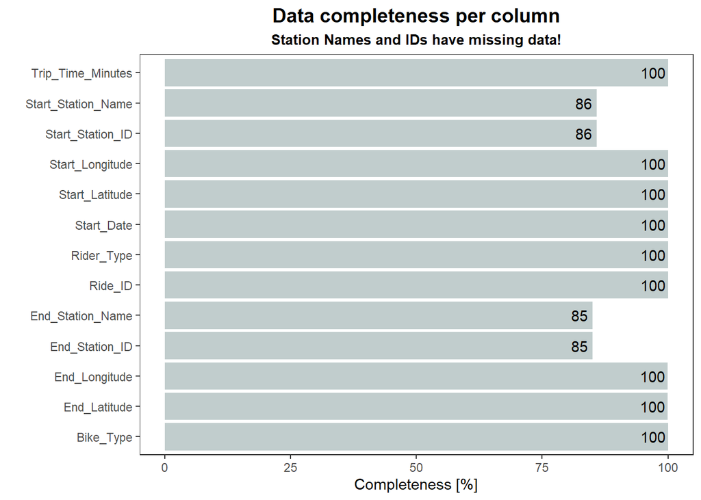

```r
# There are also missing observations for some of the columns in the head. Using
# a different function allows us to see more information about missing values and
# also unique values for each column.
df_skim <- skim_without_charts(df_clean) %>%
  print()
```

From the skim function output the following information about *unique* observations can be seen:

The location IDs consist of a code while the location names are either one or two street names (presumedly their intersection) with a “&” symbol as their denominator. There are more unique location names than location IDs, which could be for a variety or reasons. It could be misspellings, it could be due to some street names being in reverse order, or it could perhaps be due to there being more than one station per intersection. Again, delving deeper into the geographical data is not the focus of this analysis as this is instead something that I might ask a data engineer for more information in a real world problem. However, to make sure I do my due diligence in this analysis, I will export the unique values to Excel and show my observations and recommendations here.

```r
uniqueStartStations <- df_3 %>%
  select(Start_Station_ID, Start_Station_Name) %>%
  distinct()
```

```r
uniqueEndStations <- df_3 %>%
  select(End_Station_ID, End_Station_Name) %>%
  distinct()
```

```r
n_occur <- data.frame(table(uniqueStartStations$Start_Station_Name))
n_occur[n_occur$Freq > 1,]
```

```
##                               Var1 Freq
## 106                   Bradley Park    2
## 138     California Ave & Cortez St    2
## 159          Calumet Ave & 51st St    2
## 160          Calumet Ave & 71st St    2
## 196   Central Park Ave & Ogden Ave    2
## 215  Christiana Ave & Lawrence Ave    2
## 361         East End Ave & 87th St    2
## 371        Eggleston Ave & 92nd St    2
## 451          Halsted St & 111th St    2
## 461           Halsted St & 63rd St    2
## 531         Jeffery Blvd & 67th St    2
## 621          Kostner Ave & Lake St    2
## 634        Lake Park Ave & 47th St    2
## 671        Lawndale Ave & 111th St    2
## 910    Prairie Ave & Garfield Blvd    2
## 1575          Wabash Ave & 87th St    2
## 1617               WEST CHI-WATSON    2
```

```r
n_occur <- data.frame(table(uniqueStartStations$Start_Station_ID))
n_occur[n_occur$Freq > 1,]
```

```
##                                     Var1 Freq
## 19                                  1032    2
## 20                                  1033    2
## 23                                  1038    2
## 24                                  1039    2
## 70                                 13053    2
## 73                                 13059    2
## 79                                 13074    2
## 123                                13197    2
## 198                                15541    2
## 214                                15623    2
## 373                                  303    2
## 402                                335.0    2
## 456                                  390    2
## 517                                  478    2
```

[output cut: 327 more lines]

```r
n_occur <- data.frame(table(uniqueEndStations$End_Station_Name))
n_occur[n_occur$Freq > 1,]
```

```
##                                      Var1 Freq
## 100  Bissell St & Armitage Ave - Charging    2
## 106                          Bradley Park    2
## 138            California Ave & Cortez St    2
## 159                 Calumet Ave & 51st St    2
## 160                 Calumet Ave & 71st St    2
## 197          Central Park Ave & Ogden Ave    2
## 216         Christiana Ave & Lawrence Ave    2
## 362                East End Ave & 87th St    2
## 372               Eggleston Ave & 92nd St    2
## 451                 Halsted St & 111th St    2
## 461                  Halsted St & 63rd St    2
## 532                Jeffery Blvd & 67th St    2
## 622                 Kostner Ave & Lake St    2
## 635               Lake Park Ave & 47th St    2
## 671               Lawndale Ave & 111th St    2
## 913           Prairie Ave & Garfield Blvd    2
## 1600                 Wabash Ave & 87th St    2
```

```r
n_occur <- data.frame(table(uniqueEndStations$End_Station_ID))
n_occur[n_occur$Freq > 1,]
```

```
##                                     Var1 Freq
## 21                                  1032    2
## 28                                  1039    2
## 74                                 13053    2
## 77                                 13059    2
## 83                                 13074    2
## 127                                13197    2
## 202                                15541    2
## 218                                15623    2
## 377                                  303    2
## 406                                335.0    2
## 460                                  390    2
## 521                                  478    2
## 522                                  479    2
## 523                                  480    2
```

[output cut: 341 more lines]

```r
Start_stations <- createWorkbook()
addWorksheet(Start_stations, "First_Sheet")
writeData(Start_stations,"First_Sheet", uniqueStartStations)
saveWorkbook(Start_stations, file = "Start_stations_unique.xlsx", overwrite = TRUE)
```

The overlap likely means that there are many locations that should be aggregated into just one if a fair comparison were to be done for the counts of rides per location. For this reason, also due to the ~15% missing values, there is significant bias when using this data, which should be kept in mind when looking at the results so as to not make conclusions and decisions on this misleading data.

# 4. Analyzing the Questions

## 4a. How are the different bike types used by members and non-members?

Visualize the counts of rides by bike type and member/casual(non-member):

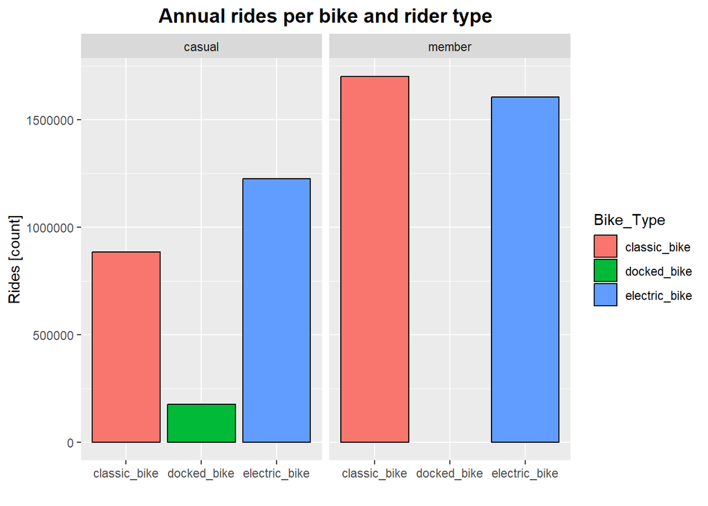

```r
df_clean %>%
  ggplot() +
  geom_bar(mapping = aes(Bike_Type, fill = Bike_Type), , color = "black") +
  facet_wrap(~Rider_Type) +
  labs(title="Annual rides per bike and rider type", x = "", y = "Rides [count]") +
  theme(plot.title = element_text(hjust = 0.5, color = "black",
                              size = 14, face = "bold"))
```

Some questions that pop up from this first graph are: * Why don’t any annual members use docked bikes at all? Are docked bikes available in the areas where they would be used? What percentage of rides are using docked bikes? * Why do casual riders prefer electric bikes and members prefer classic bikes?

## 4b. How is the trip time different for members and non-members?

To get some stats on the trip time I’ll do some * Average travel time for each bike type and membership type * Min max och each travel time for each bike type and membership type

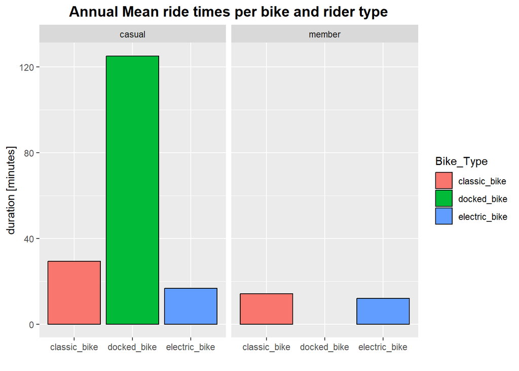

```r
df_clean %>%
  group_by(Rider_Type, Bike_Type) %>%
  summarise(mean = mean(Trip_Time_Minutes), n= n()) %>%
  ggplot(mapping = aes(x = Bike_Type,
                       y = mean,
                       fill = Bike_Type)) +
  geom_bar(stat= "identity", color = "black") +
  facet_wrap(~Rider_Type) +
  labs(title="Annual Mean ride times per bike and rider type",
       x = "",
       y = "duration [minutes]") +
  theme(plot.title = element_text(hjust = 0.5, color = "black",
                              size = 14, face = "bold"))
```

Docked bikes seem to include times that are much greater than electric and classic bikes in travel time, so this will be investigated further in a distribution.

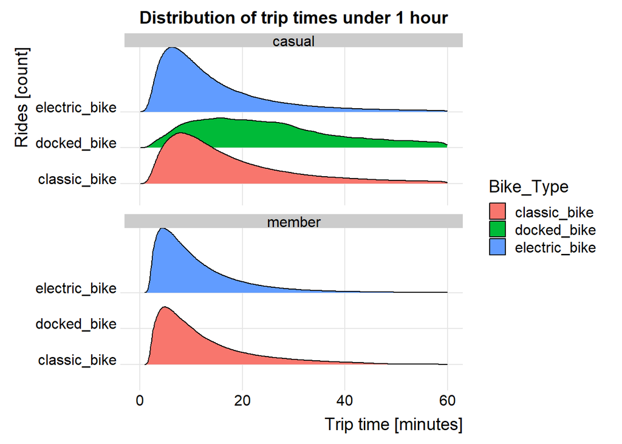

```r
ggplot(df_clean,
       aes(x = Trip_Time_Minutes,
           y = Bike_Type,
           fill = Bike_Type)
       ) +
  scale_x_continuous(limits=c(0, 60)) +
  geom_density_ridges() +
  facet_wrap(~Rider_Type, ncol = 1) +
  theme_ridges() +
  labs(title = "Distribution of trip times under 1 hour",
       x = "Trip time [minutes]", y = "Rides [count]") +
  theme(plot.title = element_text(hjust = 0.5, color = "black",
                              size = 14, face = "bold"))
```

## 4c. How are the bikes used throughout the year?

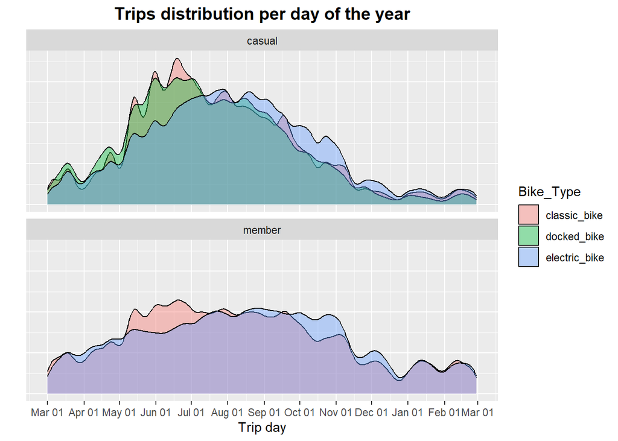

```r
ggplot(df_clean,
       aes(x = Start_Date,
           fill = Bike_Type)) +
  geom_density(alpha = 0.4) +
  scale_x_date(date_breaks = "1 months", date_labels = "%b %d") +
  facet_wrap(~Rider_Type, ncol = 1) +
  labs(title = "Trips distribution per day of the year",
       x = "Trip day", y = "") +
  theme(axis.text.y=element_blank(),  #remove y axis labels
        axis.ticks.y=element_blank()  #remove y axis ticks
        ) +
  theme(plot.title = element_text(hjust = 0.5, color = "black",
                              size = 14, face = "bold"))
```

There is not much difference between what time of year users of different bike types ride bikes except for a dip of relative electric bike usage in June.

As the summer months are where most casual riders are using the bikes, there could be an opportunity to run campaigns during these months.

```r
# ggplot(df_clean, aes(Start_Station_Name, Freq)) +
#   geom_bar(stat="identity", width = 0.5, fill="tomato2") +
#   labs(title="Bar Chart",
#        subtitle="Manufacturer of vehicles",
#        caption="Source: Frequency of Manufacturers from 'mpg' dataset") +
#   theme(axis.text.x = element_text(angle=65, vjust=0.6))
#
# df_clean %>%
#   group_by(broad_field,field) %>%
#   summarise(n=sum(n_phds, na.rm=TRUE)) %>%
#   arrange(desc(n))%>%
#   head(30)%>%
#   ggplot(aes(x=reorder(field,n),y=n, fill=broad_field)) +
#   xlab("field")+
#   geom_col() + coord_flip()
```

## 5. Evaluation and conclusions

The lack of data on station names (of about 15%) and geographical coordinates (less than 1%) can mean that the results are skewed, especially if the lack of data for these observations are not spread evenly. For example, if there are specific stations that don’t show the data, then there could be a significant difference from the reported and actual number of rides in that area.

# TO DO

I think I could shorten the text by omitting some things that don’t specifically have to do with the business task that I specifically am answering with my analysis. Alternatively use some formatting to make it different from the main text.

I could include the link to the data and be clearer with the problems with the data in a separate section in the Data Import, Exploration, and Cleaning chapter.

I could write an introduction to the analysis phase with how I organized and formatted data for the analysis, including statistical calculations.

I’m most proud of the distribution of trip times, because I felt that it was a simple way of showing that there is a difference for the bike types while also showing how they are different, all in one graph. I think I should look over the graphs again to make sure that the main messages are even clearer by checking the labels again.